# Lesson 3 | SIR Modelling in R

# Introduction

Programming tools like R are very helpful for handling complex math problems, especially in mathematical modeling. For example, they make it easier to build and use models like the SIR model we studied before.

Today, you will learn how to create and graph a SIR model in R.

Let’s get started!

# Learning objectives

By the end of this lesson, you should be able to:

- Define initial conditions and parameters for the SIR (Susceptible, Infected, Recovered) model.
- Write a function in R to represent the SIR model’s differential equations.
- Solve the SIR model’s differential equations using the {deSolve} package.
- Convert the output of the differential equations into a data frame for further analysis.
- Visualize the results of the SIR model using the ggplot2 package in R.

# Packages

This lesson will require the following packages to be installed and loaded:

```r
# Load packages
if(!require(pacman)) install.packages("pacman")
pacman::p_load(deSolve, # package to solve differential equations
               tidyverse, # package that includes ggplot2
               here)
```

# 1 R-Based Code Along

Let’s translate the theoretical concepts and differential equations we learned in the previous lesson and put them into practice by implementing a SIR model in R.

## 1.1 Setting Up the SIR Model in R

In order to set-up a compartmental model in R such as the SIR model, the following steps need to be completed:

- **Step 1**: Setting up Initial Conditions and Parameters
- **Step 2**: Writing the SIR Model Function
- **Step 3**: Solving the Differential Equations
- **Step 4**: Converting the Output to a Data Frame

### 1.1.1 Step 1: Setting Initial Conditions and Parameters

The first step of creating a SIR model in R is defining the initial conditions and parameters of the model.

As a reminder, the compartments and parameters of the SIR model are the following:

- **Susceptible (S)**: Number of individuals who can become infected (total population at risk).
- **Infected (I)**: Number of individuals who are infected and can transmit the disease.
- **Recovered (R)**: Number of individuals who have recovered and are no longer infectious.
- **Transmission coefficient (β)**: The rate at which susceptible individuals become infected.
- **Recovery rate (γ)**: The rate at which infected individuals recover.

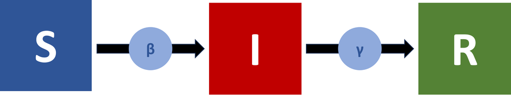

Let’s use the boarding school influenza epidemic in Northern England as an example and review the epidemiological summary to figure out the initial conditions and parameters that will need to use to create our SIR model.

**Epidemiological Summary of the Boarding School Influenza Outbreak**

In January, an influenza epidemic occurred at a boarding school in northern England, affecting **763** boys aged 10 to 18. The first case presented with illness from January 15 to 18. By January 22, three boys were in the infirmary, and the outbreak escalated rapidly.

The average illness duration was **three to seven days**, with most boys returning to class within five to six days. The virus peaked within seven days and subsided after **13 days**. Despite prior vaccination, the outbreak was rapid, likely due to an antigenic shift.

Only one adult developed symptoms. Complications were rare, with a few cases of secondary bacterial infections responding well to antibiotics.

Let’s try to identify the number of individuals for the initial conditions (Susceptible, Infected, Recovered).

Based on the epidemiological summary, the total population at risk is 763 boys. Initially, one boy is infected, known as “patient zero,” setting the number of infected individuals (I) to 1. The remaining 762 boys are susceptible (S), calculated by subtracting the infected boy from the total population (763 - 1). At the start, no individuals have recovered, so the initial number of recovered (R) is 0.

This setup accurately represents the population’s initial state as the outbreak begins.

Therefore the initial conditions are:

- **Total population:** 763 boys.
- **Initial infected (I):** 1 boy (patient zero).
- **Initial susceptible (S):** 762 boys (763 total - 1 infected).
- **Initial recovered (R):** 0 (none recovered at the start).

Based on this information we can set our initial conditions to:

$$S = 762$$

$$I = 1$$

$$R = 0$$

Now that we know our initial conditions, let’s go ahead and create a vector in R called `initial_state` that contains the value of our initial conditions for S, I and R:

```r
# Define the initial conditions
initial_state <- c(S = 762, I = 1, R = 0)

initial_state
```

```
##   S   I   R
## 762   1   0
```

We are now going to define the value of the two parameters of the SIR model - the transmission coefficient (beta) and the recovery rate (gamma).

**Deriving Transmission and Recovery Rate**

For today’s lesson we will provide you with the values we are going to use, but in a later lesson we will discuss how to calculate and derive these values according to epidemiological data.

Let’s create a vector called `parameters` containing the value of the transmission rate `beta` and the value of the recovery rate `gamma`:

```r
#Define the parameters
parameters <- c(beta = 0.0026, # Transmission rate
                gamma = 0.5)   # Recovery rate

parameters
```

```
##   beta  gamma
## 0.0026 0.5000
```

Finally, we will need to set the time span for which we want our simulation to run for. According to the influenza outbreak summary, the influenza virus spread quickly, **reaching its peak within seven days and subsiding after 13 days**. For this, we will make the duration of the simulation 2 weeks (14 days).

Let’s create a numerical vector that will include the 14 days:

```r
# Time span for the simulation
times <- seq(1, 14, by = 1)
```

### 1.1.2 Step 2: Writing the SIR Model Function

Now that we’ve set up our initial conditions and parameters, we’ll implement the SIR model using the {deSolve} package in R.

To do this, we need to start by writing a function that describes the SIR model.

We’ll define a function called `sir_model` that takes three arguments: `time`, `state`, and `parameters`. The `time` argument represents the time points for which we want to solve the model. The `state` argument is a vector containing the initial values of the compartments (S, I, R), and `parameters` is a vector containing the model parameters (β and γ).

Here is the structure of the function:

```r
sir_model <- function(time, state, parameters) {
  with(as.list(c(state, parameters)), {
    # Rate of change
    dS <- -beta * S * I
    dI <- beta * S * I - gamma * I
    dR <- gamma * I

    # Return the rate of change
    list(c(dS, dI, dR))
  })   # end with (as.list...)
}
```

Let’s break down the function and better understand what each section does:

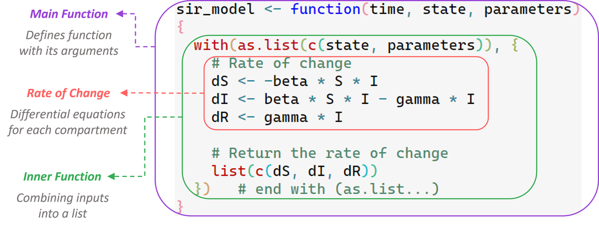

**Function Definition:**

We start by defining the function `sir_model` which will model our system of differential equations.

This function takes three arguments:

- `time`: Representing the time points
- `state`: Vector containing the current values of the compartments (S, I, R)
- `parameters`: Vector containing the model parameters (β and γ).

```r
# Define function and arguments
sir_model <- function(time, state, parameters) {

}
```

**Combining Inputs into a List:**

Within the function, we use the `with` function in combination with `as.list` to merge the `state` and `parameters` into a single list.

This step allows us to access the elements of `state` and `parameters` directly by their names, simplifying the subsequent calculations.

```r
  with(as.list(c(state, parameters)), {

  })
```

**Calculating Rates of Change:**

Next, we calculate the rate of change for each compartment using the model equations.

**The Ordinary Differential Equations of the SIR Model**

The SIR model is governed by the **three** following differential equations.

$$\frac{dS}{dt} = - \beta SI$$

$$\frac{dI}{dt} = \beta SI - \gamma I$$

$$\frac{dR}{dt} = \gamma I$$

Where: $\beta$ is the transmission rate, and $\gamma$ is the recovery rate.

We will need to use the **ordinary differential equations** for the **SIR model** that we learned from Lesson 2, where:

- `dS` calculates the rate of change of the susceptible population. It is given by `-beta * S * I`, reflecting the decrease in susceptible individuals as they become infected.
  $${dS} = - \beta SI$$
- `dI` calculates the rate of change of the infected population. It is determined by `beta * S * I - gamma * I`, representing the increase due to new infections and the decrease due to recovery.
  $${dI} = \beta SI - \gamma I$$
- `dR` calculates the rate of change of the recovered population. It is given by `gamma * I`, indicating the rate at which infected individuals recover.
  $${dR} = \gamma I$$

Written in our function as follows:

```r
    dS <- -beta * S * I
    dI <- beta * S * I - gamma * I
    dR <- gamma * I
```

**Returning the Rates of Change:**

Finally, we return the rates of change as a list. This list contains the computed values of `dS`, `dI`, and `dR`, which represent the rates at which the compartments change over time.

```r
  # Return the rate of change
  list(c(dS, dI, dR))
```

### 1.1.3 Step 3: Solving the Differential Equations

In order to solve the differential equations of our SIR model, we will use the `ode` function from the {deSolve} package.

**Understanding the {deSolve} Package**

The {deSolve} package in R is a powerful tool for numerically solving differential equations. It provides functions to solve initial value problems for systems of ordinary differential equations (ODEs), partial differential equations (PDEs), differential algebraic equations (DAEs), and delay differential equations (DDEs). The versatility of {deSolve} makes it suitable for a wide range of applications, including those derived from converting PDEs to ODEs through numerical differencing.

For more details on the {deSolve} package, please refer to the [deSolve package documentation](https://desolve.r-forge.r-project.org/).

We can use the `ode()` function from the {deSolve} package to solve the ordinary differential equations.

The function `ode()` requires **4 arguments**:

- `y` represents the initial state of the compartments (S, I, R).
- `times` is the sequence of time points over which we want to solve the equations.
- `func` is the model function `sir_model` that defines the rate of change for each compartment.
- `parms` is the vector of parameters (β and γ) used in the model.

```r
sir_out <- ode(
  # inital state
  y = initial_state,
  # sequence of time points
  times = times,
  # model function
  func = sir_model,
  # parameters in the model
  parms = parameters
  )
```

### 1.1.4 Step 4: Converting the Output to a Data Frame

Finally, we convert the output to a data frame for easier manipulation and visualization:

```r
sir_out <- as.data.frame(sir_out)

head(sir_out)
```

```
##   time        S          I          R
## 1    1 762.0000   1.000000   0.000000
## 2    2 757.4764   4.378541   1.145025
## 3    3 738.2384  18.669334   6.092261
## 4    4 665.3583  71.560775  26.080949
## 5    5 475.8399 196.609239  90.550887
## 6    6 243.5974 300.089003 219.313576
```

## 1.2 Visualizing the Results

To visualize the dynamics of the SIR model, we will create a plot using the ggplot2 package where we will graph all three predicted lines (S, I, R):

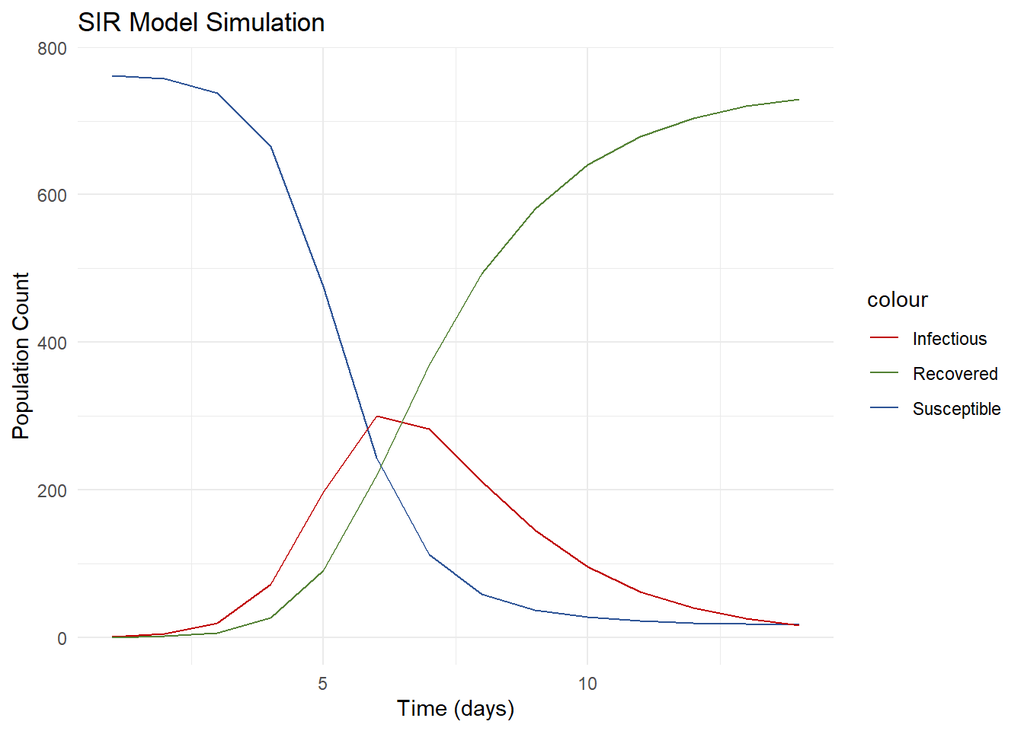

```r
# Create a plot to visualize the dynamics of the SIR model
ggplot(sir_out, aes(x = time)) +
  # Graph Susceptible line
  geom_line(aes(y = S, color = "Susceptible")) +
  # Graph Infected line
  geom_line(aes(y = I, color = "Infectious")) +
  # Graph Recovered line
  geom_line(aes(y = R, color = "Recovered")) +
  # Add title and labels
  labs(title = "SIR Model Simulation", x = "Time (days)", y = "Population Count") +
  # Specify color for each line
  scale_color_manual(values = c("Susceptible" = "#2F5597", "Infectious" = "#C00000", "Recovered" = "#548235")) +
  # Select theme
  theme_minimal()
```